RESEARCH ARTICLE

Current State of MRI-Guided Endovascular

Arterial Interventions: A Systematic Review

of Preclinical and Clinical Studies

Han Nijsink, MSc,<sup>1</sup>*

Christiaan G. Overduin, PhD,<sup>1</sup>Loes H. Willems, MD,<sup>2</sup>

Michiel C. Warlé, MD, PhD,<sup>2</sup>and Jurgen J. Fütterer, MD, PhD<sup>1</sup>

Background: MRI guidance of arterial endovascular interventions could be beneﬁcial as it does not require radiation expo-

sure, allows intrinsic blood-tissue contrast, and enables three-dimensional and functional imaging, however, clinical appli-

cations are still limited.

Purpose: To review the current state of MRI-guided arterial endovascular interventions and to identify the most commonly

reported challenges.

Study Type: Systematic review.

Population: Pubmed, Embase, Web of Science, and The Cochrane Library were systematically searched to ﬁnd relevant

articles. The search strategy combined synonyms for vascular pathology, endovascular therapy, and real-time MRI

guidance.

Field Strength/Sequence: No ﬁeld strength or sequence restrictions were applied.

Assessment: Two reviewers independently identiﬁed and reviewed the original articles and extracted relevant data.

Statistical Tests: Results of the included original articles are reported.

which data were extracted from 43 articles (6 phantom, 33 animal, and 4 human studies). Reported technical success rates

for animal and human studies ranged between 42% to 100%, and the average complication rate was 5.8% (animal studies)

and 8.8% (human studies). Main identiﬁed challenges were related to spatial and temporal resolution as well as safety,

design, and scarcity of current MRI-compatible endovascular devices.

Data Conclusion: MRI guidance of endovascular arterial interventions seems feasible, however, included articles included

mostly small single-center case series. Several hurdles remain to be overcome before larger trials can be undertaken. Main

areas of research should focus on adequate imaging protocols with integrated tracking of dedicated endovascular

devices.

J. MAGN. RESON. IMAGING 2022;56:1322–1342.

T

o reduce surgical impact, vascular surgery has been

mainly replaced by minimally invasive endovascular inter-

ventions. Currently, ﬂuoroscopy is the standard imaging

modality to guide these endovascular procedures. This tech-

nique, however, coincides with radiation exposure, and the

administration of contrast agents. Contrary to ﬂuoroscopy,

magnetic resonance imaging (MRI) provides high soft-tissue

contrast without the use of radiation and contrast agents,

since blood itself can be utilized as an intrinsic contrast

agent.<sup>1</sup>This might be beneﬁcial for especially young patients

and patients with renal impairment. Additional advantages of

MRI guidance might improve endovascular procedures. First,

three-dimensional (3D) information can be acquired to

improve

anatomical

perception.

Second,

functional

View this article online at wileyonlinelibrary.com. DOI: 10.1002/jmri.28205

Received Feb 10, 2022, Accepted for publication Apr 4, 2022.

*Address reprint requests to: H.N., Department of Medical Imaging, Radboudumc, Geert Grooteplein Zuid 10, 6525 GA, Nijmegen, The Netherlands.

E-mail: han.nijsink@radboudumc.nl

From the <sup>1</sup>Department of Medical Imaging, Radboudumc, Nijmegen, Netherlands; and <sup>2</sup>Department of Surgery, Radboudumc, Nijmegen, Netherlands

Additional supporting information may be found in the online version of this article

This is an open access article under the terms of the Creative Commons Attribution-NonCommercial License, which permits use, distribution and reproduction

in any medium, provided the original work is properly cited and is not used for commercial purposes.

© 2022 The Authors. Journal of Magnetic Resonance Imaging published by Wiley Periodicals LLC

on behalf of International Society for Magnetic Resonance in Medicine.

1322

information like ﬂow and perfusion parameters can be

obtained, which may provide insight into the outcomes of

the intervention and may lead to additional adjustments

within the same procedure.<sup>2</sup>Finally, MRI guidance can

potentially enable minimally invasive bypass surgery, since

the 3D imaging and high soft-tissue contrast make the

guidewire visible outside the vascular system.

The scope of this review is narrowed down to review

MRI-guided endovascular arterial interventions. Although the

ﬁrst experiments of MRI-guided arterial endovascular inter-

ventions using tracking devices were already described in

1993,<sup>3</sup>research regarding clinical implementation in human

has been scarce. The requirements that must be met before

MRI guidance can be safely used, can potentially explain the

low level of interest for MRI guidance. An important require-

ment is the MRI compatibility and visibility of endovascular

devices such as guidewires and catheters, which poses a com-

plex problem both from a physics and engineering perspec-

tive.<sup>4</sup>Successful methods have been developed for device

visualization using active and passive techniques to track end-

ovascular devices, for example, for cardiac interventions

(Figure 1).<sup>5</sup>Another requirement for proper MRI guidance is

the preservation of high-quality images while maintaining an

adequate acquisition frame rate.<sup>5</sup>Furthermore, working

within the MRI environment poses additional challenges

related to patient access, in-room image feedback and team

communication (Figure 2). Nevertheless, recent progress on

MRI-guided cardiac catheterization and ablation within the

cardiac ﬁeld showed promising methods which can be trans-

lated to arterial interventions.<sup>6,7</sup>

Several articles have been covering the different require-

ments for MRI-guided endovascular interventions and have

been evaluating various device-tracking techniques and MRI

sequences to optimize the guidance.<sup>8</sup><sup>–</sup><sup>10</sup>Furthermore, reviews

have been reporting MRI-guided endovascular and cardiac

interventions in general,<sup>11</sup><sup>–</sup><sup>15</sup>describing the different device-

tracking techniques, imaging sequences, and possible clinical

applications. However, a clear and comprehensive overview of

relevant clinical outcomes is not available. Furthermore, an

overview

of

described

pitfalls

and

other

challenges

described in current literature might be useful to clarify the<sup>as</sup>

stagnant clinical implementation. Hence, the purpose of this

work was to review the feasibility of arterial endovascular

interventions in phantom, animal, and clinical studies and to

identify reported issues that pose the main challenges for clin-

ical implementation.

Materials and Methods

This systematic review was performed in accordance with the PRI-

SMA guidelines and the protocol which was used to guide this

review

is

registered

in

the

PROSPERO

database

(CRD42019125516). To provide an extensive overview of the ﬁeld,

we extended our search and included phantom and animal studies.

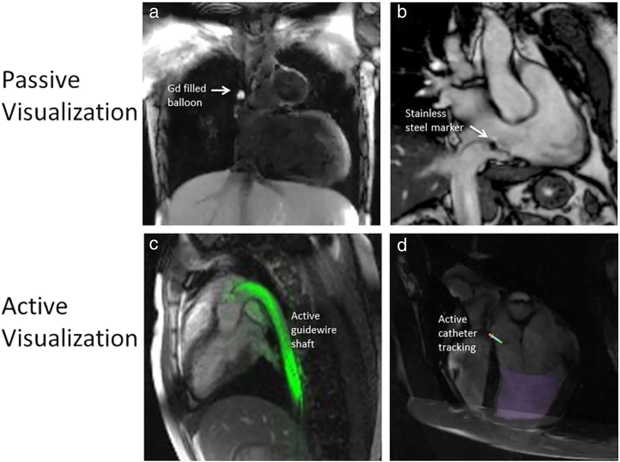

FIGURE 1: Examples of active and passive devices visualization. (a) Gadolinium-ﬁlled balloon tip catheter in the superior vena cava.

(b) Stainless steel imaging marker on a passive catheter. (c) Color overlay of the active guidewire (loopless antenna) depicting the

entire device shaft in-plane. (d) Active tracking coils to overlay catheter tip position and orientation on a preacquired image. The

image is required from “real-time MRI guidance of cardiac interventions” by Campbell-Washburn et al.<sup>5</sup>Copyright permission

obtained.

November 2022

1323

Nijsink et al.: Current State of MRI-Guided Endovascular Arterial Interventions

Literature Search

To evaluate the available literature on arterial endovascular interven-

tions, we performed a systematic search. A librarian was consulted

for the search strategy. Details of the search strategy are shown in

Supporting Information SA. In short, the search consisted of the fol-

lowing three components; vascular pathology, endovascular therapy,

and real-time MRI guidance. Pubmed, Embase, Web of Science,

and The Cochrane Library were systematically searched. Reference

lists of systematic reviews that were identiﬁed within the search, were

screened for missing but relevant articles.

Data Collection

The articles retrieved from the search were imported in endnote and

duplicates were automatically removed.<sup>16</sup>Afterwards, two readers

(L.W. and H.N.) independently screened the title and abstract of

the remaining articles. Studies were selected for full-text screening if

the inclusion criteria for human studies, as shown below, were met

according to at least one of the readers. Full-text articles were

retrieved and reviewed and disagreements were resolved via consen-

sus or by consulting a third author (J.F.). Screening and selection of

the preclinical studies were performed by one reader. Rayyan QCRI,

a free web-based tool, was used throughout the screening process.<sup>17</sup>

Study Selection Criteria

Studies describing clinically relevant outcomes after MRI-guided

endovascular arterial interventions were included in this review.

Articles were excluded if the technical success was not reported.

Furthermore, articles were only eligible for inclusion if they reported

the number of subjects, subject types and, intervention types.

All matching studies until September 2021 were included without

restrictions on study type or language. Studies regarding cardiac,

valvular,

venous,

and

(chemo)embolization

interventions

were

excluded.

Data Extraction

Data extraction for human studies was conducted by two reviewers

(L.W. and H.N.) and disagreements were discussed and solved via

consensus or by consulting a third author (J.F.). Using a structured

data collection form, the following data were retrieved: the last name

of the ﬁrst author, full title, publication year, intervention type, out-

come parameters, results, and sample size. Furthermore, details

regarding MRI ﬁeld strength, real-time MRI sequences, and used

devices were extracted. Data extraction for phantom and animal

studies was performed similarly by one observer. Study outcomes are

presented using descriptive statistics. Due to heterogeneity of the

data, the small subject sizes, and the lack of relevant control groups

within the studies, risk of bias assessment and meta-analysis were

not performed.

Results

Eligible Studies

Using

the

search

strategy,

presented

in

Supporting

abstract screening. Using the title and abstract screening,

were included for data extraction. Screening the reference list

of the relevant reviews provided one additional eligible article,

which was also included in the data extraction process. The

PRISMA 2020 ﬂowchart (Figure 3) illustrates the details of

the selection process. The interrater agreement was 99.3% for

the title and abstract selection process and 95.7% for the full-

text selection process. Disagreements were resolved using con-

sensus by both observers.

Study Characteristics

A total of 43 studies were ﬁnally included. Six studies

described

phantom

experiments

only.

Interventions

in

[figure not shown]

FIGURE 2: Example setup for MRI-guided endovascular interventions in a wide-bore 3-T MRI environment within a hybrid procedure

room. Patient access is restricted while the patient is positioned at the center of the scanner bore during real-time imaging. The

interventionalist should maneuver the endovascular device while observing the image feedback on an in-room display, illustrating

challenges of in-bore vascular interventions.

1324

Volume 56, No. 5

Journal of Magnetic Resonance Imaging

animals were performed in 33 of 43 studies with one study

also describing phantom experiments.<sup>9</sup>The retrieved data is

summarized in Table 1. The interventions in the phantom

and animal studies were balloon angioplasty (14/39), ste-

nting

(16/39),

embolectomy

(1/39),

aneurysm

repair

(1/39), or a combination of balloon angioplasty and ste-

nting (7/39).

Four out of the 43 selected studies (9.3%) described

MRI-guided endovascular interventions in humans. One

arteries (15 patients), aortic coarctations (5 patients), and

hemodialysis access grafts (4 patients). The human studies

were performed in institutions located in Europe (Germany

(3/4), the Netherlands (1/4)). All human studies were publi-

shed in 2006 or earlier.

The maximum number of living subjects (human or

animal) within the selected studies was 15. Four studies com-

pared MRI-guided endovascular interventions with ﬂuoros-

copy guidance,<sup>41,42,56,57</sup>two studies compared outcomes for

active and passive tracking,<sup>2,10</sup>and one study evaluated the

effect of low and high main magnetic ﬁeld on the out-

comes.<sup>38</sup>The deﬁnition of technical success, as deﬁned by

each article, was reported and differed amongst the varying

studies. Examples of reported technical outcomes are artery

diameter change, change in functional parameters, and

whether or not the stent was correctly placed.

Details regarding MRI ﬁeld strength, sequence, and

devices used for the different studies are summarized in

Table 2. The most frequently used ﬁeld strength was 1.5 T

and the sequences used for real-time imaging were mainly

gradient echo or steady-state free precession sequences.

Study Outcomes

TECHNICAL SUCCESS AND CLINICAL OUTCOMES. The

technical success, as deﬁned by the authors of each study, was

100% in the six phantom studies, however, the sample size in

ﬁve of six studies was one. Within the 33 animal studies,

technical success ranged between 42% and 100%. A total of

functional parameters, all of which showed improvement after

MRI-guided endovascular interventions.

The technical success within human studies ranged

from 50% to 93%. Out of 38 interventions, 31 were success-

ful, resulting in an overall success rate of 82%. The study

from Bartels et al only succeeded to perform angioplasty in

two of four subjects. The reason for the failed attempts was

frequent arm motion in one patient and recoiling of the ste-

nosis in another patient.<sup>18</sup>All reported clinical outcomes,

such as the ankle-brachial index, reduction of stenosis, ﬂow,

and arterial diameter, showed improvement after MRI-guided

procedures.

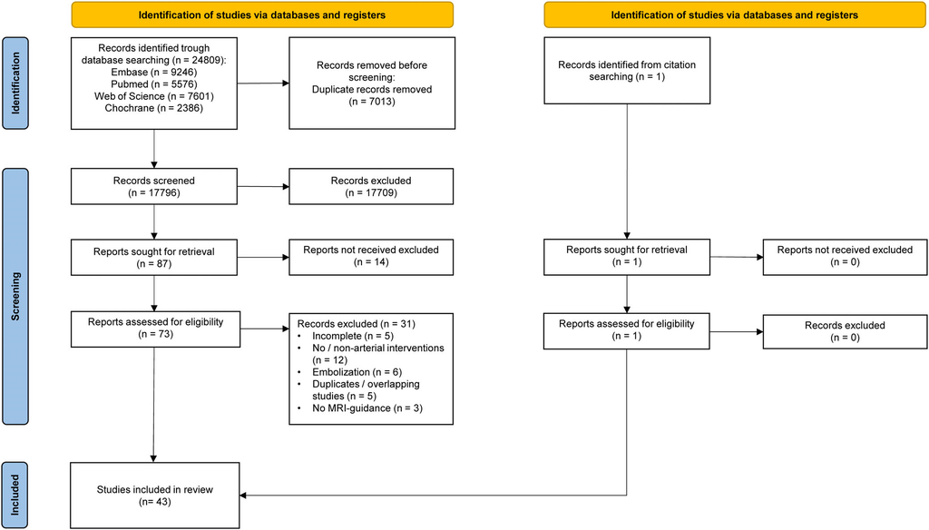

FIGURE 3: PRISMA 2020 ﬂowchart.

November 2022

1325

Nijsink et al.: Current State of MRI-Guided Endovascular Arterial Interventions

TABLE 1. Study Characteristics and Outcomes

Study

Study Design

Subject type

Intervention type

Total sample size

Outcome measures

Outcomes

Procedure times (a) and

complications (b)

Reported challenges/

disadvantages

Human studies

Bartels et al18

Prospective pilot

study

Human

Hemodialysis graft

PTA

4

a) Technical success

b) Flow increase

a) 2/4

b) 270 mL/min

a) N.A.

b) N.A.

-Low spatial and temporal

resolution

-Manual slice adjustment

-Poor device visibility

Paetzel et al19

Prospective pilot

study

Human

Femoral and

popliteal artery

PTA

15

a) Technical success

b) Stenosis reduction

a) 14/15

b) 57%

a) 31.1 (22–55) minutes

b) No complications

-Poor device visibility

-Device safety concerns

-Lack of real-time imaging

-Usability of guidewire

Krueger et al20

Prospective pilot

study

Human

Aortic coarctation

PTA

5

a) Technical success

b) Arterial diameter

a) 4/5

b) 7.8 mm before,

13.36 mm after the

procedure

a) N.A.

b) No complications

-Poor device visibility and

device safety

-Manual slice adjustment

-No automatic device

detection

Manke et al21

Prospective pilot

study

Human

Iliac artery PTA

and stenting

14

a) Technical success

b) Ankle brachial

index

a) 11/14

b) 0.71 before, 0.93 after

procedure

a) 73.3 (47–122) minutes

b) Subintimal recanalization

(1), misplaced stent (1),

minor groin hematoma

(3), femoral artery

pseudoaneurysm (1)

-Long procedure times

-Lack of real-time

monitoring

-Large stent artifacts

Animal studies

Bücker et al22

Pilot study

Pig

External iliac artery

stenting

3

Technical success

3/3

a) 15–30 minutes for

preparation, 8 minutes for

stent deployment

b) N.A.

-Long procedure times

-Limited patient access

Yang et al23

Pilot study

Rabbit

Aortic PTA

2

Technical success

2/2

a) N.A.

b) N.A.

-Low frame rate

-Low SNR

Quick et al24

Pilot study

Sheep

Aortic stenting

2

Technical success

2/2

a) N.A.

b) N.A.

-Large stent artifacts

-Device safety

Buecker et al25

Pilot study

Pig

Iliac artery stenting

7

Technical success

7/7

a) 15 minutes for

preparation, 6 minutes (4–

7) from insertion to the

deployment of the stent

b) Incomplete stent

deployment (due to

accidentally partially

removing stent from the

catheter before the

procedure

-Low temporal and spatial

resolution

-Latency of MRI

acquisition

-Limited patient access

1326

Volume 56, No. 5

Journal of Magnetic Resonance Imaging

TABLE 1. Continued

Study

Study Design

Subject type

Intervention type

Total sample size

Outcome measures

Outcomes

Procedure times (a) and

complications (b)

Reported challenges/

disadvantages

Dion et al26

Pilot study

Swine

Aortic and iliac

artery stenting

5 (3 aorta, 2 iliac

arteries)

a) Technical success

b) Deviation of

planned stent

position

a) 5/5

b) 7.8 mm (0–22 mm)

a) 20 minutes for

preparation, 13 minutes

(12–15) from starting in

the distal iliac artery to

deployment

b) Stent migration of

22 mm

-Learning curve

-Low temporal and spatial

resolution

-Device design/usability

-Exclusion criteria for MRI

Godart et al9

Pilot study

Pig and

phantom

Aortic PTA and

stenting

Pig: PTA (5),

stenting (1)

Phantom: PTA (1)

a) Technical success

b) Stent position

a) Phantom: 1/1; pig: 4/5

(PTA), 1/1 (stenting)

b) Correct stent placement

a) 45 minutes (without

intubation and femoral

puncture)

b) No complications

-Low framerate

-Device visibility

Le Blanche

et al27

Pilot study

Rabbit

Renal artery PTA

15 (30 arteries)

Technical success

22/30

a) N.A.

b) N.A.

-Low temporal resolution

Omary et al28

Comparative pilot

study (MRI

versus

ﬂuoroscopy)

Swine

Real artery PTA

4 (3/6 arteries,

1 artery was

totally occluded,

1 had no

occlusion)

a) Technical success

b) Stenosis percentage

c) Arterial diameter

MRI: a) 3/3; b) 76.7%

before, 41.6% after

procedure; c) 1.6 mm

before, 2.6 mm after the

procedure

Fluoroscopy: a) 1/1; b)

90% before, 80% after

procedure; c) 0.5 mm

before, 1.0 mm after

procedure

MRI: a) approximately

90 minutes; b) N.A.

Fluoroscopy: a) N.A.; b)

N.A.

-Low temporal resolution

-Unavailability of devices

-Limited patient access

-No monitor in the MRI

room

Yang et al29

Pilot study

Rabbit

Aortic PTA

8

a) Technical success

b) Time-to-peak (CE-

MRI)

a) 8/8

b) 2 minutes before, 30–

40 sec after the

procedure

a) N.A.

b) N.A.

-Poor guidewire visibility

-Device safety

Buecker et al30

Pilot study

Pig

Iliac artery PTA

6 (9 arteries)

Technical success

6/9

a) N.A.

b) N.A.

-Low robustness of device-

tracking

-Device visibility

-Low framerate

Keuhne et al31

Pilot study

Swine

Pulmonary artery

stenting

4

Technical success

4/4

a) N.A.

b) No complications

-Device safety and design/

usability

-Partial visibility of

guidewire

-Large stent artifacts

-Radiofrequency shielding

within the stent lumen

November 2022

1327

Nijsink et al.: Current State of MRI-Guided Endovascular Arterial Interventions

TABLE 1. Continued

Study

Study Design

Subject type

Intervention type

Total sample size

Outcome measures

Outcomes

Procedure times (a) and

complications (b)

Reported challenges/

disadvantages

Wacker et al32

Pilot study

Pig

Renal and iliac

artery PTA and

stenting

4 (4 renal arteries

and 2 iliac

arteries)

a) Technical success

b) Deviation of

planned stent

position (range)

a) 6/6

b) 7.3 (2–13) mm

a) Range (54–90 minutes)

b) Renal artery rupture (due

to using an 8-mm balloon

in a 4-mm artery)

-Large stent artifact

-Low spatial and temporal

resolution

-Limited patient access

-Device safety

Kuehne et al33

Pilot study

Swine

Aortic, carotid, and

iliac artery

stenting

5

Technical success

7/7

a) N.A.

b) No complications

-Difﬁcult to produce the

device

Mahnken et al34

Pilot study

Swine

Aortic PTA and

aortic grafting

4

Technical success

4/4

a) N.A.

b) Occlusion of the renal

artery (lack of introducer

sheath caused dislocation)

-Large artifact size

Feng et al35

Pilot study

Swine

Carotid artery

stenting

5 (10 arteries)

Technical success

10/10

a) N.A.

b) No complications

-Device visibility

Raval et al2

Comparative pilot

study (active vs.

passive tracking)

Swine

Stent placement in

aortic

coarctation

13

a) Technical success

b) Lumen diameter

c) Reduction of peak

instantaneous

gradient pressure

d) Reduction of peak-

to-peak systolic

gradient

Active: a) 8/8

Passive: a) 5/5

Both active and passive: b)

5 � 1 mm before,

11 � 1 after surgery (all

13 animals); c)

8 � 7 mmHg (all 13

animals); d)

4 � 3 mmHg (all 13

animals)

Active: a) 26 � 11 minutes

Passive: a) 106 �

42 minutes, b)

Coarctation rupture due

to oversized balloon (1)

-Device heating

Raman et al36

Pilot study

Swine

Abdominal

aneurysm repair

11

Technical success

9/11

a) N.A.

b) Endoleak (2)

-Unavailability of proper

MRI endografts

Terashima37

Pilot study

Rabbit

Aortic PTA and

stenting

8

Technical success

Angioplasty: 8/8

Stent placement: 2/2

a) N.A

b) No complications

-Low temporal and spatial

resolution

-Requirement of a 3D

roadmap

Wacker et al38

Comparative pilot

study (0.2 vs.

1.5 T MRI)

Pig

Renal artery PTA

and stenting

7

a) Technical success

b) Deviation of

planned stent

position (range)

0.2 T a) 4/4, b) 7.3 (2–

13) mm

1.5 T a) 3/3, b) 6.8 (2.4–

12.7) mm

0.2 T a) range 54–

90 minutes, b) N.A.

1.5 T a) range 18–

29 minutes, b) N.A.

-Limited patient access

(1.5 T)

-Low temporal and spatial

resolution (0.2 T)

-Long procedure times

(0.2 T)

-Low accuracy of stent

position

-Device safety and design/

usability

1328

Volume 56, No. 5

Journal of Magnetic Resonance Imaging

TABLE 1. Continued

Study

Study Design

Subject type

Intervention type

Total sample size

Outcome measures

Outcomes

Procedure times (a) and

complications (b)

Reported challenges/

disadvantages

Eggebrecht

et al39

Pilot study

Swine

Aortic stenting

8

a) Technical success

b) Arterial diameter

a) 8/8

b) 0.9 cm (0.825–0.975)

before, 2.05 cm (1.925–

2.1) after procedure

(P = 0.066)

a) 2 (2–4) minutes

b) Severe arrhythmia with

hemodynamic instability

-Device visibility

-Device safety

Elgort et al40

Pilot study

Swine

Renal artery

stenting

6

a) Technical success

b) Stenosis percentage

c) Deviation of

planned stent

position

a) 6/6

b) 53.6% before, 14.9%

after procedure

c) 0.98 � 0.69

a) 25 minutes (including

15 minutes for 3D

imaging)

b) No complications

-Device visibility

Omary et al41

Comparative pilot

study (MRI

versus

ﬂuoroscopy)

Swine

Renal artery PTA

11

a) Technical success

b) Stenosis percentage

MRI: a) 9/11 (P = 0.5),

b) 63% � 10 before,

19% � 16 after

procedure

Fluoroscopy: 11/11

(P = 0.5), b)

71% � 10 before,

23% � 16 after

procedure

MRI: a) 77 � 46 minutes,

b) arterial dissection (3)

Fluoroscopy: a)

31 � 18 minutes, b)

arterial dissection (1)

-Unavailability of proper

MRI devices

-Long procedure times

-Low temporal and spatial

resolution

Raval et al42

Comparative pilot

study (MRI vs.

ﬂuoroscopy)

Swine

Carotid artery PTA

(chronic total

occlusion)

14

Technical success

MRI: 11/14

Fluoroscopy: 1/3

MRI: a) 55 � 22 minutes,

b) extravascular

hematoma after wire

exiting artery

Fluoroscopy: a) 45 minutes,

b) contrast extravasation

after wire exiting artery,

arterial dissection with

lethal mediastinal

hematoma

-Low temporal and spatial

resolution

-Device design/usability

Saeed et al43

Pilot study

Dog

Stent placement in

aortic

coarctation

8

a) Technical success

b) Flow

c) Arterial pressure

(lower extremity)

a) 7/8

b) 0.2 L/minute before,

0.8 L/minute after the

procedure

c) 51 mmHg before,

117 mmHg after the

procedure

a) Typically 15–20 minutes

b) Death after perforation of

a severe coarctation (1)

-Device safety

-Low temporal and spatial

resolution

November 2022

1329

Nijsink et al.: Current State of MRI-Guided Endovascular Arterial Interventions

TABLE 1. Continued

Study

Study Design

Subject type

Intervention type

Total sample size

Outcome measures

Outcomes

Procedure times (a) and

complications (b)

Reported challenges/

disadvantages

Krombach

et al44

Pilot study

Pig

Iliac artery PTA

5 (10 arteries)

a) Technical success

b) Stenosis criteria

a) 9/10

b) Severe before, to mild

after the procedure: 5,

severe/mild stenosis

before, to no stenosis

after the procedure: 4

a) N.A.

b) Perforation of the iliac

artery (1)

-The price of suitable

guidewires

Frericks et al10

Comparative pilot

study (active vs.

passive tracking)

Swine

Renal artery

stenting

6

a) Technical success

b) Deviation of

planned stent

position

Active: a) 3/3, b)

4 � 2 mm

Passive: a) 3/3, b) 10 � 3

Active: a) 17 minutes, b)

N.A.

Passive: a) 23 minutes, b)

N.A.

-Manual plane adjustment

-Accuracy of stent

placement

Kos et al45

Pilot study

Swine

Aortic stenting

2 (1 abdominal/1

thoracic)

a) Technical success

b) Stent position

(autopsy)

a) 2/2

b) Correct position

a) 12 (thoracic) and 10

(abdominal) minutes

b) N.A.

-Unavailability of suitable

guidewires

-No automated marker

tracking

Kos et al8

Pilot study

Swine

Renal artery PTA

and stenting

2 (eight times

angioplasty, four

stents)

Technical success

12/12

a) 10 � 2 minutes

(angioplasty),

12 � 3 min. (stenting)

b) No complications

-Large artifacts

-Marker visibility

-Optimization of sequence

required

Kos et al46

Pilot study

Swine

Iliac and supra-

aortic artery

PTA and

stenting

3 (3

brachiocephalic,

3 subclavian,

and 6 iliac

arteries)

Technical success

12/12

a) 8 minutes

(brachiocephalic),

5 minutes (subclavian),

7 minutes (iliac)

b) N.A.

-Manual plane alignment

-Passive visibility of both

guidewire and catheter

-Fixed artifact size

Kramer et al47

Pilot study

Pig

Inguinal artery

stenting, renal

artery PTA

5 (1 inguinal

stenting, 10

renal arteries)

Technical success

11/11

a) N.A.

b) no complications

-Preplanning of imaging

plane

-Marker visibility

-Device safety

-Acoustic noise

Neizel et al48

Pilot study

Pig

Iliac artery PTA

6 (12 arteries, of

which 4 arteries

were stenotic)

a) Technical success

b) Stenosis percentage

a) 12/12

b) 70–99% before, to 0%

(n = 3) and < 50%

(n = 1) after surgery

a) N.A.

b) No complications

N.A.

Massman et al49

Pilot study

Swine

Aortoiliac and

visceral artery

PTA and

stenting

9

a) Technical success

b) Stent position

a) 9/9

b) Stent positioning within

5 mm of target

a) N.A.

b) No complications

-Unavailability of suitable

devices

1330

Volume 56, No. 5

Journal of Magnetic Resonance Imaging

TABLE 1. Continued

Study

Study Design

Subject type

Intervention type

Total sample size

Outcome measures

Outcomes

Procedure times (a) and

complications (b)

Reported challenges/

disadvantages

Yang et al50

Pilot study

Pig

Embolectomy

within the

carotid artery

4 (13 carotid

arteries)

Technical success

11/13

a) N.A

b) N.A.

-Device safety and design/

usability

-Long time to manually

determine marker

location

Phantom studies

Stroman

et al51

Feasibility study

Arterial graft

Stenting

1

Technical success

1/1

a) N.A

b) N.A.

-Unavailability of suitable

devices

Smits et al52

Feasibility study

Flow phantom

on the arm

of a

volunteer

PTA

1

a) Technical success

b) Flow

a) 1/1

b) 480 mL/minute before,

1080 mL/minute after

procedure

a) N.A

b) N.A.

-Device safety

-Flexibility of imaging

van der Weide

et al53

Feasibility study

Stenosed tube

on arm of a

volunteer

PTA

1

Technical success

1/1

a) N.A

b) N.A.

-Time-consuming manual

MRI plane adjustment

Mekle et al54

Feasibility study

Phantom

PTA

1

Technical success

1/1

a) N.A.

b) N.A.

-Difﬁcult to distinguish

between two passive

devices

Attia et al55

Feasibility study

Aortic

phantom

Stenting

1

Technical success

1/1

a) N.A.

b) N.A.

Guidewire design/usability

Rube et al56

Comparative pilot

study (MRI vs.

ﬂuoroscopy)

Phantom

PTA

39

a) Technical success

b) Peak velocity

MRI: a) 30/30, b) 20–

25 cm/sec before, 10–

12 cm/sec after

procedure

Fluoroscopy: a) 9/9, b)

N.A.

MRI: a) 9 minutes (6–111),

b) N.A.

Fluoroscopy: a) 9 minutes

(6–11), b) N.A.

-Device design/usability

patient access

-Sterility

-Manual plane adjustment

CE-MR: contrast-enhanced magnetic resonance imaging; N.A.: not available; PTA: percutaneous transluminal angioplasty; SNR: signal-to-noise ratio.

November 2022

1331

Nijsink et al.: Current State of MRI-Guided Endovascular Arterial Interventions

TABLE 2. MRI Field Strength, Sequence, and Endovascular Device Types Used in the Included Studies

Study

Field

strength

Tracking sequence

Endovascular device type

Human studies

Bartels

et al<sup>18</sup>

1.5 T

2D GRE, TR/TE: 14/9.2 msec, FA:

10<sup>�</sup>, ST: N.A., FR: 0.5 fps

Plastic coated glass ﬁber guidewire and

nonbraided balloon catheters, both enhanced

with paramagnetic dysprosium oxide ring-

markers (Cordis Europa N.V., Roden, The

Netherlands)

Paetzel

et al<sup>19</sup>

1.5 T

2D FLASH, TR/TE: 11/5.64 msec,

FA: 25<sup>�</sup>, ST: 6 mm, FR: 2 fps

Guidewire (Terumo; Leuven, Belgium), balloon

catheter (Wanda, Boston Scientiﬁc; Ratingen,

Germany)

Krueger

et al<sup>20</sup>

1.5 T

SSFP with radial k-space ﬁlling,

TR/TE: 3.3/1.6 msec, FA: 45<sup>�</sup>, ST:

6–8 mm, FR: 9 fps

Custom-made 0.035-inch PEEK guidewire,

balloon catheter (Tyshak II, NuMed,

Ontario, Canada)

Manke

et al<sup>21</sup>

1.5 T

2D FLASH with ﬂow compensation.

TR/TE: 14.0/6.1 msec. FA: 30<sup>�</sup>, ST:

8 mm, FR: 0.53 fps

Nitinol guidewire (Cope; Cook, Bloomington,

Ind & Terumo, Tokyo, Japan), angiographic

catheter (Cook), self-expanding nitinol stent

(Memotherm; Bard-Angiomed, Karlsruhe,

Germany), angioplasty balloon catheter (Blue

Max; Meditech/Boston Scientiﬁc, Watertown,

MA)

Animal studies

Bücker

et al<sup>22</sup>

1.5 T

GRE, TR/TE: 8.4/3.6 msec, FA: 10<sup>�</sup>,

ST: 8.5 mm, FR: 0.33 fps

Self-expandable stent (Cook Europe,

Bjaeverskov, Denmark) within an MR-

compatible catheter

Yang et al<sup>23</sup>

1.5 T

Fast-spoiled GRE, TR/TE:

9.9/2.5 msec, FA: N.A., ST: 5 mm,

FR: 4.2 fps

Custom-made loopless catheter antenna,

balloon catheter (MediTech/Boston Scientiﬁc,

Watertown, MA)

Quick

et al<sup>24</sup>

1.5 T

FGRE, TR/TE: 7.7/3.6 msec, FA: 10<sup>�</sup>,

ST: N.A., FR: 2 fps

Two active (electrical dipole and coaxial line)

custom-made stents created using stainless

steel wall stents from Schneider (Bülach,

Switzerland)

Buecker

et al<sup>25</sup>

1.5 T

GRE with radial k-space ﬁling, TR/TE:

8.4–13.4/3.3–3.6 msec, FA: 8–13<sup>�</sup>,

ST: 8.5–10 mm, FR: 20 fps

Prototype nitinol stent (ZA stent, Cook Europe,

Bjaeverskov, Denmark), nitinol guidewire

(Cook Europe), ﬁberglass guidewire with

multiple dysprosium markers (Cordis, Roden,

The Netherlands), balloon catheter (Cordis)

with dysprosium markers

Dion et al<sup>26</sup>

0.5 T

GRE, TR/TE: 13.2/44.9 msec, FA:

30<sup>�</sup>, ST: N.A, FR: 0.1/0.2 fps

Guidewire (Glidewire; Terumo, Somerset, NJ),

iliac stent deployment system (Angiomed;

Bard, Karlsruhe, Germany)

Godart

et al<sup>9</sup>

0.2 T

FLASH, TR/TE: 120/14 msec, FA:

30–50<sup>�</sup>, ST: 10 mm, FR: 0.1 fps

Radifocus guidewire (Terumo Europe, Leuven,

Belgium) with iron oxide nanoparticles,

balloon catheter (Cristal, Balt Extrusion,

Montmorency, France), Easy Wallstent

(Schneider (Europe), Bülach, Switzerland)

Le Blanche

et al<sup>27</sup>

1.5 T

Winch Guidewire (Nycomed Amersham

Medical Systems, Paris, France), monorail

1332

Volume 56, No. 5

Journal of Magnetic Resonance Imaging

TABLE 2. Continued

Study

Field

strength

Tracking sequence

Endovascular device type

T2-weighted turbo SE, TR/TE:

59/4.2 msec, FA: 140<sup>�</sup>, ST: 6 mm,

FR: 0.15 fps

coronary angioplasty balloon catheter

(Manﬁeld, Meditech, Boston, MA)

Omary

et al<sup>28</sup>

1.5 T

Time-resolved 3D, TR/TE:

5.8/1.4 msec, FA: 30<sup>�</sup>, ST: 2.6 mm,

FR: 0.4 fps

Time-resolved 3D, TR/TE:

5.7/1.4 msec, FA: 30<sup>�</sup>, ST:40 mm,

FR: 0.9 fps

Single-phase 3D, TR/TE: 6.2/1.6 msec,

FA: 45<sup>�</sup>, ST: 1 mm, Acquisition

time: 21.4 s

Nitinol guidewire (Boston Scientiﬁc,

Watertown, MA), 5F cobra selective visceral

catheter, balloon catheter

Yang et al<sup>29</sup>

1.5 T

Fast-spoiled GRE, TR/TE:

5.0/1.4 msec, FA: N.A., ST: N.A.,

FR: 3 fps

Custom-made loopless catheter antenna,

balloon catheter (MediTech/Boston Scientiﬁc,

Watertown, MA)

Buecker

et al<sup>30</sup>

1.5 T

GRE, TR/TE: 12/2.2 msec, FA: 10<sup>�</sup>,

ST: 10 mm, FR: 20 fps

Balloon catheter (Cordis, Roden, The

Netherlands) with micro coils

Keuhne

et al<sup>31</sup>

1.5 T

bSSFP, TR/TE: 3.4/1.7 msec, FA: 60<sup>�</sup>,

ST: 5–30 mm, FR: 2.2 fps

T1-weighted turbo ﬁeld echo, TR/TE:

3.9/1.3 msec, FA: 60<sup>�</sup>, ST: 5–

30 mm, FR: 2.0 fps

0.035-inch guide wire (Microvena, White Bear

Lake, Minn), self-expanding nitinol stent

(Memotherm; Angiomed, Karlsruhe,

Germany)

Wacker

et al<sup>32</sup>

0.2 T

2D spoiled GRE, TR/TE:

5.0/2.0 msec, FA: 25<sup>�</sup>, ST: 6–8 mm,

FR: 1.6 fps

Guidewire (Radifocus; Terumo, Tokyo, Japan),

prototype guidewire (Ferro Tip; Somatex),

prototype catheter (Somatex, Berlin,

Germany), balloon catheter (Ultra Thin;

Boston Scientiﬁc, Watertown, Mass), balloon-

expandable stents (Palmaz; Cordis, Miami,

Fla), self-expandable stents (Symphony;

Boston Scientiﬁc)

Kuehne

et al<sup>33</sup>

1.5 T

SSFP, TR/TE: 1.99/1.6 msec, FA: 5<sup>�</sup>

or 45<sup>�</sup>, ST: 8–10 mm, FR: 8 fps

0.035-inch polyester and nitinol guidewire,

custom-made stent delivery system with

resonance circuit, nitinol stents (Flexx;

Angiomed, Karlsruhe, Germany)

Mahnken

et al<sup>34</sup>

1.5 T

2D GRE with spiral k-space ﬁlling,

TR/TE: 31/4.9 msec, FA: 26<sup>�</sup>, ST:

10 mm, FR: 10 fps

Amplatz Super-Stiff ST035/180, (Boston

Scientiﬁc, Natick, MA), excluder stent-graft,

(W.L. Gore and Associates, Flagstaff, AZ)

Feng et al<sup>35</sup>

1.5 T

GRE, TR/TE: N.A., FA: 20–35<sup>�</sup>, ST:

30 mm, FR: 9–15 fps

Guidewire (Terumo; Boston Scientiﬁc, Natick,

Mass), self-expanding nitinol stents (Smart

Stent; Cordis, Miami, Fla), 5-F catheter

Raval et al<sup>2</sup>

1.5 T

SSFP, TR/TE: 3.5/1.7 msec, FA: 60<sup>�</sup>,

ST: 6 mm, FR: 8 fps

Intercept guidewire (Surgi-Vision), nitinol

guidewire (Glidewire, Terumo/Boston

Scientiﬁc), platinum–iridium stents

(Cheatham Z stent, NuMed Inc), balloon-in-

balloon dilatation catheter (BIB, NuMed),

prototype cobalt–nickel–chromium alloy

(MP35N) stent (Medtronic)

November 2022

1333

Nijsink et al.: Current State of MRI-Guided Endovascular Arterial Interventions

TABLE 2. Continued

Study

Field

strength

Tracking sequence

Endovascular device type

Raman

et al<sup>36</sup>

1.5 T

SSFP, TR/TE: 3.8/1.8 msec, FA: 60<sup>�</sup>,

ST: 8 mm, FR: 4–8 fps

Custom-made active guidewire, nitinol

endograft (Vanguard, Boston Scientiﬁc,

Natick, MA), three custom-made active self-

expanding endograft designs

Terashima<sup>37</sup>

1.5 T

Self-developed interleaved spiral

acquisition, TR/TE: 27.0/4.6 msec,

FA: 30<sup>0</sup>, ST: 5 mm, FR: 16–20 fps

Stainless steel guidewire (Guidant Corp., Santa

Clara, CA, USA), nitinol guidewire (Terumo

Corp., Tokyo, Japan), balloon catheter (ACS

RX COMET, Guidant Corp.), stent (Pulse

Medical Systems, Collegeville, PA, USA)

Wacker

et al<sup>38</sup>

0.2 and

1.5 T

0.2 T: 2D spoiled GRE, TR/TE:

5.0/2.0 msec, FA: 25<sup>�</sup>, ST: 6–8 mm,

FR: 1.6 fps

1.5 T: 2D spoiled GRE, TR/TE:

5.0/3.0 msec, FA: 70<sup>�</sup>, ST: 5–7 mm,

FR: 3 fps

Prototype “Ferro Tip” guidewire (Somatex,

Teltow, Germany), hydrophilic-coated

guidewire (35-inch Radifocus, Terumo,

Tokyo, Japan), 5–6 F prototype catheters,

(Somatex, Teltow, Germany), commercially

available balloon catheters, balloon-

expandable stents (Palmaz, Corinthian; Cordis

Corporation, Miami Lakes, FL) (Omniﬂex;

Angiodynamics, Queensbury, NY)

Eggebrecht

et al<sup>39</sup>

1.5 T

TrueFisp, TR/TE: 3/1.5 msec, FA: 80<sup>�</sup>,

ST: 6 mm, FR: 7 fps

Self-expandable stent-graft device (GoreTAG,

W.L. Gore Inc., Flagstaff, AZ)

Elgort

et al<sup>40</sup>

1.5 T

TrueFisp, TR/TE: 4.43/2.22 msec, FA:

70<sup>�</sup>, ST: 5 mm, FR: NA

Guidewire (0.035- inch Radifocus; Terumo,

Tokyo, Japan), angiographic catheter (Torcon

NB Advantage Angiographic Catheter; Cook,

Bloomington, IN), balloon catheter

(OmniFlex; Angio Dynamics, Queensbury,

NY), stent (Palmaz P204 Balloon-Expandable

Intraluminal Stent; Johnson & Johnson,

Warren, NJ)

Omary

et al<sup>41</sup>

1.5 T

Active: SSFP, TR/TE: 2.9/1.45 msec,

FA: 70<sup>�</sup>, ST: 30 mm, FR: 9 fps

Passive: GRE, TR/TE: 2.3/1.45 msec,

FA: 20<sup>�</sup>, ST: 30 mm, FR: 7 fps

Loopless antenna guidewire coil (Intercept;

Surgi-Vision, Gaithersburg, Md), 5-F aortic

catheter, renal artery catheter, balloon catheter

(Cordis Europa, Roden, The Netherlands)

Raval et al<sup>42</sup>

1.5 T

SSFP, TR/TE: 3.5/1.7 msec, FA: 45<sup>�</sup>,

ST: 4 mm, FR: N.A.

Custom-made active gold–silver–gold-plated

nitinol wires with MP35N (cobalt–chromium

alloy) micro coils and tungsten-braided

catheters (Minnesota Medtec) with 1-cm

micro coils, adjusted nitinol guidewire

(Nitrex, ev3)

Saeed

et al<sup>43</sup>

1.5 T

bFFE, TR/TE: 3.7/1.9 msec, FA: 70<sup>�</sup>,

ST: 5–30 mm, FR: 5 fps

Nitinol guidewire (AGA Medical Corp., Golden

Valley, MN), self-expanding nitinol stent

(Symphony, Boston Scientiﬁc Corp.,

Watertown, MA)

Krombach

et al<sup>44</sup>

1.5 T

SSFP, TR/TE: 2.5/1.25 msec, FA: 45<sup>�</sup>,

ST: 8 mm, FR: N.A.

Standard guidewire (Terumo, Tokyo, Japan),

standard balloon catheter (Boston Scientiﬁc,

Glen Falls, NY)

Frericks

et al<sup>10</sup>

1.5 T

TrueFISP, TR/TE: 5/2.5 msec, FA:

70<sup>�</sup>, ST: 5–7 mm, FR: 3 fps

Prototype “Ferro Tip” guidewire (Somatex,

Teltow, Germany), steerable hydrophilic-

1334

Volume 56, No. 5

Journal of Magnetic Resonance Imaging

TABLE 2. Continued

Study

Field

strength

Tracking sequence

Endovascular device type

coated wire (35-inch Radifocus; Terumo,

Tokyo, Japan), C-1 catheter (Somatex),

balloon catheter (Ultra Thin; Boston

Scientiﬁc, Watertown, MA), balloon-

expandable Palmaz Corinthian stent (Cordis

Corporation, Miami Lakes, FL), Omni Flex

stent (Angiodynamics, Queensbury, NY)

Kos et al<sup>45</sup>

1.5 T

GRE T1-FLASH, TR/TE:

8.12/5.24 msec, FA: 21<sup>�</sup>, ST: 5 mm,

FR: 2/3 fps

Guidewire (Biotronik Vascular Intervention,

Buelach, Switzerland) with iron oxide

nanoparticles (MagnaFy; MagnaMedics

GmbH, Aachen, Germany), balloon catheter

(Pheron, Biotronik), self-expandable stent

(Astron, Biotronik), self-expandable stent

(Wallstent; Boston Scientiﬁc, Maple Grove,

MN)

Kos et al<sup>8</sup>

1.5 T

TrueFISP, TR/TE: 5.3/5.2 msec, FA:

80<sup>�</sup>, ST: 10 mm, FR: 1 fps

Guidewire (Biotronik Vascular Intervention,

Buelach, Switzerland) with iron oxide

nanoparticles (MagnaFy; MagnaMedics

GmbH, Aachen, Germany), vertebral catheter

(SOFTouch, Merit Medical, Galway,

Ireland), 4-French Cobra 2 catheter (Merit

Medical) both enhanced with Magnafy

markers

Kos et al<sup>46</sup>

1.5 T

GRE T1-FLASH, TR/TE:

8.12/5.24 msec, FA: 21<sup>�</sup>, ST: 5 mm,

FR: 2/3 fps

Stent (Peiron, Biotronik, Buelach, Switzerland),

nonbraided 4 French vertebral catheter

(SOFTouch, Merit Medical, Galway,

Ireland), self-expandable nitinol stent (Astron,

Biotronik), nonbraided Shepherd Flush

catheter (Merit Medical), balloon catheter

(Pheron, Biotronik), balloon-expandable stent

(Peiron, Biotronik)

Kramer

et al<sup>47</sup>

1.5 T

bSSFP, TR/TE: 2.6/1.3 msec, FA: 40<sup>�</sup>

or 50<sup>�</sup>, ST: 8 mm, FR: 3.4 fps

Custom-made ﬁberglass compound wire, cobra

angiography catheter (Supertorque 65 cm,

0.038,” Cordis), ACN1 angiography catheter

(Cook Inc.), cobra angiography catheter

(Glidecath 5F, 65 cm, Terumo, Japan),

balloon catheter, microcatheter (Terumo,

Japan), self-expanding stent catheter (Jostent

SelfX, Abbott Vascular Devices, The

Netherlands)

Neizel

et al<sup>48</sup>

3 T

SSFP, TR/TE: 3/1.3 msec, FA: 8<sup>�</sup>, ST:

8 mm, FR: N.A.

Cooke guidewire (Cook Bloomington, IN),

cobra catheter (Cook), balloon catheter

(Aachen Resonance, Aachen, Germany), drug-

eluting balloon “Elutax SV” (Aachen

Resonance)

Massman

et al<sup>49</sup>

1.5 T

bSSFP, TR/TE: 283/2.18 msec, FA:

60<sup>�</sup>, ST: 10 mm, FR: 5 fps

Custom-made aramid guidewires with small

iron particles, Radiofocus Glidecath Cobra

catheter (Terumo Europe, Leuven, Belgium)

November 2022

1335

Nijsink et al.: Current State of MRI-Guided Endovascular Arterial Interventions

COMPLICATIONS. The 33 included animal studies per-

formed a total of 277 interventions. Complications were

reported during 16 interventions, resulting in a complication

rate of 5.8%. The reported complications were: arterial dis-

section (3), endoleak (2), artery rupture/perforation (2), death

after perforation of aortic coarctation (2), extravascular hema-

toma after wire perforation of the artery (1), contrast extrava-

sation after wire exiting artery (1), arterial dissection with

lethal mediastinal hematoma (1), renal artery occlusion (1),

severe arrhythmia with hemodynamic instability (1), incorrect

TABLE 2. Continued

Study

Field

strength

Tracking sequence

Endovascular device type

Yang et al<sup>50</sup>

1.5 T

bSSFP, TR/TE: 3.9/2.0 msec, FA: 10–

20<sup>�</sup>, ST: 8 mm, FR: 1.5 fps

Custom-made PEEK ﬁber thread catheter with

an embedded wireless resonant circuit

Phantom studies

Stroman

et al<sup>51</sup>

1.5 T

FSE, TR/TE: N.A., FA: N.A., ST:

3 mm, FR: 0.25 fps

Custom-made Teﬂon-coated ﬁber-optic

guidewire with gold-plated tip, Cragg

EndoPro system (MinTec, Endotech Ltd.,

Freeport, Grand Bahama, The Bahamas)

Smits

et al<sup>52</sup>

1.5 T

GRE with keyhole technique, TR/TE:

15/8 msec, FA: 10<sup>�</sup>, ST: 30 mm, FR:

1.5 fps

Fiber-optic guidewire (Cordis, Roden, The

Netherlands) with dysprosium oxide rings,

nonbraided angioplasty balloon catheter

(Cordis) with dysprosium oxide rings

van der

Weide

et al<sup>53</sup>

1.5 T

GRE, TR/TE: 15/9 msec, FA: 10<sup>�</sup>, ST:

50 mm, FR: 0.5 fps

Custom-made guidewire with ﬁve dysprosium

rings, balloon catheter with two dysprosium

rings

Mekle

et al<sup>54</sup>

1.5 T

bSSFP, TR/TE: 4.31/2.14 msec, FA:

3<sup>�</sup>, ST: 40 mm, FR: 0.9 fps

T1-weighted FLASH, TR/TE: 3.17/

1.0 msec, FA: 70<sup>�</sup>, ST: 40 mm, FR:

1.1 fps

Custom-made PEEK polymer guidewire with

iron particle coating (Biotronik vascular

intervention, Beulach, Switzerland), standard

catheter (Schneider GmbH, Beulach,

Switzerland), balloon catheter (FOX PTA

catheter, Abbot Laboratories Vascular

Enterprises Ltd., Beringen, Switzerland)

Attia et al<sup>55</sup>

1.5 T

2D FLASH, TR/TE: 2.36/0.83 msec,

FA: 25<sup>�</sup>, ST: 20 mm, FR: 2 fps

Fiber-optic guidewire (SEDI, Couronnes,

France) with titanium oxide markers

(Magpaint Europe, Veldhunten, The

Netherlands), angiographic catheter (Terumo,

Tokyo, Japan) with titanium oxide markers,

Valiant stent-graft (Medtronic Vascular, Santa

Rosa, CA)

Rube et al<sup>56</sup>

1.5 T

bSSFP, TR/TE: 4.8/6.9 msec, FA: 70<sup>�</sup>,

ST: 5 mm, FR: N.A.

spiral bSSFP, TR/TE: 3.5/20 msec, FA:

70<sup>�</sup>, ST: 7 mm, FR: N.A.

FGRE, TR/TE: 3/7.4 msec, FA:

≤30/60<sup>�</sup>, ST: 5 mm, FR: N.A.

Prototype guidewire (EPﬂex GmbH, Dettingen/

Erms, Germany) with iron oxide

nanoparticles (MagnaFy; MagnaMedics

GmbH, Aachen, Germany), Straight catheter

(Beacon Tip Royal Flush, Cook Ine.,

Bloomington, IN), multipurpose catheter

(Soft-Vu, AngioDynamics, Latham, NY),

PTA Balloon catheter (Workhorse IT,

AngioDynamics, Latham, NY). All catheters

were enhanced with a resonant circuit

bFFE: balanced fast ﬁeld echo; (b)SSFP: (balanced) steady-state free precession; FA: ﬂip angle; (f)GRE: (fast) gradient echo; FLASH: fast

low angle shot; FR: frame rate; N.A.: not available; (f)SE: (fast) spin echo; ST: slice thickness; TrueFISP: true fast imaging with steady-

state precession; TR/TE: repetition time/echo time; 2D: two-dimensional; 3D: three-dimensional.

1336

Volume 56, No. 5

Journal of Magnetic Resonance Imaging

TABLE 3. Challenges Related to MRI-Guided Endovascular Interventions and the Number of Articles Discussing the

Challenges

Challenges

Number of articles discussing

the challenges (% from total

included articles)

Current state/potential solution

Low temporal/spatial

resolution

17/43 (39.5%)

Faster MRI techniques continue to evolve and

improve. Dedicated imaging protocols are

required per application

Device visibility

14/43 (33.3%)

Knowledge of the effects of MRI and marker

parameters can be used to optimize device

visibility. Devices that are integrated with tracking

and/or scanner imaging control could be highly

beneﬁcial

Device safety

13/43 (30%)

Several MRI-compatible CE and FDA-approved

devices are currently available.<sup>4</sup>However, more

different device types are required to catheterize

all arteries and enable more intervention types.

Furthermore, besides safety, the usability and

design should be adequate. If the incentive for

MRI-guided endovascular interventions will

increase, the industry will likely resolve the issues

regarding safety, usability, and availability of

devices

Usability/design of guidewire

8/43 (18.6%)

See “Device safety”

Unavailability of devices

8/43 (18.6%)

See “Device safety”

Limited patient access

6/43 (13.9%)

Improvements in low-ﬁeld MRI can facilitate better

patient access and acceptable interventional

imaging capabilities<sup>21</sup>

Lengthy procedure times

4/43 (9.3%)

An integrated workﬂow utilizing automatic device

tracking and image plane adjustment could

reduce procedure times. In addition, the

procedure time is expected to decrease while

progressing through the learning curve

Other challenges related to

MRI only: Manual slice

alignment (7)

Tracking issues (4)

No monitor in MRI room (1)

Acoustic noise (1)

Sterility issues (1)

Requirement of a 3D roadmap

(1)

MRI-related exclusion criteria

(1)

Latency of MRI acquisition

(1)

14/43 (33.3%)

Automatic slice adjustment and tracking can be

realized by novel artiﬁcial intelligent-based

systems. The absence of physical monitors,

acoustic noise, and sterility issues currently do not

withhold other disciplines from performing

interventions using MRI guidance

Other challenges related to

MRI and guidewire: Large

stent artifacts (5)

10/43 (23.3%)

Although speciﬁc stents that induce smaller

susceptibility artifacts are available, and lumen

visualization can be improved by reducing

radiofrequency artifacts.<sup>58,59</sup>stent artifacts will

November 2022

1337

Nijsink et al.: Current State of MRI-Guided Endovascular Arterial Interventions

stent placement (1) and incomplete stent deployment (1). In

22 studies, the presence or absence of complications has not

been reported.

Out of four human studies, only one study reported

complications, namely the study of Manke et al.<sup>21</sup>In this

study subintimal recanalization (1), misplacement of the stent

(1), minor groin hematoma (3), and femoral artery pseudo-

aneurysm (1) occurred. Complications were absent in two

other human studies, whereas one study did not report the

presence or absence of complications. Neglecting the groin

complications, which are unrelated to the choice of imaging

modality, a total of three complications occurred in 34 inter-

ventions (8.8%).

PROCEDURE TIMES. The procedure time was reported in

one phantom study. The mean procedure time for MRI-

guided balloon angioplasty was 9 minutes.<sup>56</sup>Out of the

33 animal studies, 17 reported procedure times, with times

ranging from 2 to 123 minutes. It must be noted that the

deﬁnition of procedure times was different for the various

studies and was, in general, not clearly speciﬁed. One study

compared the procedure times for MRI-guided renal angio-

plasty in swine with ﬂuoroscopy guidance, with a mean pro-

cedure time of 77 � 46 minutes for MRI guidance and

31 � 18 minutes for ﬂuoroscopy guidance.<sup>41</sup>Raval et al

compared procedure times for angioplasty in chronic total

Two human studies reported the total procedure time,

with mean times of 73.3 minutes for both angioplasty and

stent placement<sup>21</sup>and 31.1 minutes for angioplasty alone.<sup>19</sup>

The procedure times ranged between 22 and 122 minutes.

Both studies showed a steep learning curve, with average

times of 91 and 38.8 minutes in the ﬁrst part of the cohort,

and 60 and 26.2 minutes in the second part of the cohort.

COMPARATIVE STUDIES. From the selected studies, seven

studies (one phantom, six animal) made a comparison of

the

outcomes

between

MRI

guidance

and

ﬂuoroscopy

guidance,<sup>41,42,56,57</sup>tracking techniques (active versus passive),<sup>2,10</sup>

or between low and high main magnetic ﬁeld MRI.<sup>38</sup>In phan-

tom experiments, Rube et al did not ﬁnd differences in proce-

dure time and success rate between MRI and ﬂuoroscopy

guidance.<sup>56</sup>Inferior results for MRI guidance compared to ﬂuo-

roscopy in terms of success rate, procedure time, and the num-

ber of complications for renal angioplasty in swine were

reported by Omary et al.<sup>41</sup>On the other hand, Raval et al

reported superior results for MRI guidance to treat chronic total

occlusions in swine, showing higher success rates and fewer

complications compared to ﬂuoroscopy guidance.<sup>42</sup>Raval et al

reported shorter procedure times for active tracking compared to

the use of passive marker devices for balloon angioplasty in ani-

mals.<sup>2</sup>This is in concordance with results reported by Frericks

et al.<sup>10</sup>Furthermore, the results showed a lower stent placement

accuracy for passive tracking in renal arteries in swine. The com-

parison between low and high magnetic ﬁeld in MRI guidance

made by Wacker et al showed reduced procedure times for

higher magnetic ﬁelds but did not show large differences in

technical success rate or stent placement accuracy in pigs.<sup>38</sup>

CURRENT CHALLENGES. Several challenges for MRI-guided

endovascular interventions are described within the included

articles (Table 3). From the total of 43 included articles,

42 studies reported one or more challenges. MRI-related chal-

lenges were most often mentioned, with low spatial and/or

temporal resolution being a major hurdle and discussed in

17/43 articles. Furthermore, device visibility, safety, and prac-

tical issues (ie, time-consuming manual slice steering, acoustic

noise, and limited patient access) were identiﬁed as challeng-

ing factors.

Discussion

This review objectiﬁes outcomes for MRI-guided arterial end-

ovascular treatments and shows that proper investigation of

the clinical value of these procedures is still limited. Overall,

only four studies were identiﬁed that performed MRI-guided

endovascular procedures in humans and none of those

compared the outcomes with ﬂuoroscopy, the current gold

standard. Phantom, animal, and human studies showed that

MRI-guided endovascular interventions are feasible, promising,

TABLE 3. Continued

Challenges

Number of articles discussing

the challenges (% from total

included articles)

Current state/potential solution

Low stent placement accuracy

(2)

No artifact size adjustment (2)

Radiofrequency shielding

within stent lumen (1)

Required learning curve (1)

keep causing visibility issues. It is advised to take

these issues into consideration for procedures

where stenting is required

1338

Volume 56, No. 5

Journal of Magnetic Resonance Imaging

and showed improved postprocedural clinical outcomes. How-

ever, the selected eligible studies were predominantly preclinical

or phase I studies, showing the need for additional research to

evaluate the feasibility and clinical relevance of MRI-guided

endovascular interventions.

In general, clinical outcomes, such as arterial diameter,

ankle-brachial index, and arterial ﬂow, improved after MRI-

guided endovascular treatment. The reported outcomes in the

included human studies showed a technical success rate of

MRI-guided endovascular procedures comparable to the suc-

cess rate of peripheral arterial disease patients treated by con-

ventional endovascular interventions (76.8%).<sup>60</sup>However,

since no comparative human studies are available, it is difﬁ-

cult to directly compare these results. The mean complication

rate

for

MRI-guided

arterial

endovascular

interventions

reported in the included studies is in concordance with com-

plication rates of 3% to 33% for ﬂuoroscopy-guided endo-

vascular interventions, as reported in literature.<sup>61</sup>It should

be, however, noted that the results reported in this review are

extracted from studies with great heterogeneity and varying

complexity. Furthermore, the sample size of the studies was

rather small, making the outcomes less reliable and certainly

prone to underestimation because of the learning curve asso-

ciated with implementing new techniques.

The procedure times for MRI-guided endovascular

procedures are in line with the average times required for

ﬂuoroscopy-guided

PTA

and

stenting

(30

minutes

3 hours).<sup>62</sup>The required procedure time, however, depends on<sup>to</sup>

the technical difﬁculty and intervention type. Animal and

phantom studies that did directly compare MRI guidance with

ﬂuoroscopy guidance showed comparable or prolonged proce-

dure times for MRI-guided procedures. Although longer proce-

dure times are expected for MRI guidance due to several

factors, for example, manual slice adjustments, lower temporal

resolution, and suboptimal tracking, it must be considered that

the MRI-guided procedures in the included studies were novel

and the procedure times will likely decrease after users gain

more experience. The effect of the learning curve has been

demonstrated by three included studies as their results showed

a reduction in procedure times after several procedures.<sup>19,21,42</sup>

This review showed that the clinical performance in

terms of technical success, complication rates, and clinical

outcomes appears promising, but that the use of MRI guid-

ance is still associated with several challenges. A frequently

mentioned disadvantage of MRI guidance was related to the

spatial and temporal resolution, resulting in low image qual-

ity. Suboptimal image quality, in combination with manual

and additional steps such as manual slice steering, device visi-

bility, and the use of a 3D roadmap were limiting the use of

MRI guidance and likely prolonged procedure times, in par-

ticular, in early application stages. Also, device visibility,

safety, and usability were reported to be poor. Several studies

have already investigated how the different drawbacks of

MRI-guided arterial interventions can be overcome. First of

all, several techniques for visualizing the device, such as active

and passive tracking have been proposed and improved. Visi-

bility in passive tracking can be improved by changing the

ferromagnetic properties of the markers or by altering MRI

parameters.<sup>63</sup><sup>–</sup><sup>65</sup>Furthermore, negative and positive contrast

can be combined to track different devices simultaneously.<sup>66</sup>

MRI sequences with optimized signal-to-noise ratio (SNR)

and improved device visibility have been proposed in several

articles.<sup>66,67</sup>Active tracking using loop coils or resonant coils

enable tracking of multiple devices in real-time with an accu-

racy of approximately 1 mm.<sup>68</sup>Heating issues related to

active tracking should be taken into consideration, but it can

be mitigated by using saline coolant<sup>69</sup>or MRI-compatible

materials. Although frame rates �4 frames per second can be

sufﬁcient

during

ﬂuoroscopy

guidance,<sup>70</sup>

MRI

imaging

sequences using interleaved spiral acquisition can be used to

acquire frame rates of up to 20 frames per second and have

been proposed to guide endovascular interventions.<sup>37</sup>These

sequences may resolve the issues of low temporal resolution

mentioned in the included articles.<sup>71,72</sup>Spatial resolution and

SNR are inversely correlated and determine the image quality.

The minimum required SNR and resolution, however, will

vary for different vessel sizes and marker visibility. In general,

the spatial resolution should at least be sufﬁcient to visualize

the target vessel, that is, voxel size smaller than the targeted

vessel.

Reports

investigating

MR-guided

endovascular

interventions should include SNR measurements to facilitate

better comparison of imaging protocols and come to recom-

mendations on optimized image quality. High-ﬁeld MRI sys-

tems (≥1.0 T) can be used to improve the SNR and further

optimize the balance between temporal and spatial resolution,

however, high-ﬁeld MRI is associated with increased suscepti-

bility artifacts and increased safety risks. Contrary to closed

bore high-ﬁeld MRI systems, open low-ﬁeld MRI (<1.0 T)

systems enable improved patient access.<sup>41</sup>An alternative tech-

nique, besides MRI or ﬂuoroscopy guidance, is (intravascular)

ultrasound guidance.<sup>73,74</sup>This modality can provide addi-

tional detailed anatomical and functional information during

the endovascular intervention. Ultrasound guidance is, how-

ever, limited because it hardly penetrates bone, is reﬂected at

tissue–air interfaces, and is operator-dependent.

Availability of suitable MRI-compatible endovascular

devices with CE or FDA approval for use in MRI is crucial,

however many studies reported that suitable devices are

scarcely available.<sup>75</sup>Besides the good visibility, the physical

characteristics of the device, such as torque, steerability, and

risk for device kinking should be comparable to, or better

than the current devices. At the moment, a limited number

of CE-, or FDA-approved MRI-compatible guidewires are

commercially available.<sup>4</sup>If more MRI-conditional devices

become available, faster clinical implementation of MRI-

guided endovascular interventions is possible.<sup>76</sup>

November 2022

1339

Nijsink et al.: Current State of MRI-Guided Endovascular Arterial Interventions

In the included articles, the time-consuming manual

adjustment of imaging planes was considered cumbersome.

Protocols that allow communication with, and controlling of

the MRI system in combination with automatic marker

detection can replace this manual task, reducing the proce-

dure time. Several studies have been investigating these tech-

niques with promising results in preclinical studies.<sup>77</sup><sup>–</sup><sup>80</sup>

Finally, automatic detection and plane adjustment can be

coupled to a robotic manipulator to control the motion of

the endovascular devices. This enables physicians to perform

the procedure without being hindered by limited patient

access.

Although the abovementioned solutions have been pro-

posed and potentially make the barrier to embrace MRI-

guided endovascular procedure lower, the actual clinical

implementation of MRI-guided interventions is still limited.

A reason for this lack of adoption might be the absence of

clinical demand for the advantages of MRI in relation to the

accompanying disadvantages and costs. It can, therefore, be

anticipated that MRI guidance will not be implemented in

standard procedures due to high costs, insufﬁcient quality of

real-time imaging, and limited patient access. In these situa-

tions, the standard ﬂuoroscopy guidance is a cheap and con-

venient technology, serving the requirements for appropriate

guidance without the MRI-related safety risks. On the other

hand, the advantages of MRI guidance in speciﬁc cases, for

example, in pediatric or renal impaired patients, might be

substantial, since the lack of radiation and the functional

imaging capabilities could lead to better outcomes. Also,

unconventional procedures, such as minimally invasive endo-

vascular bypass surgery, which are impossible using 2D ﬂuo-

roscopy guidance, can potentially be realized using the

advantages of MRI. Furthermore, diagnostic outcomes, such

as pulmonary vascular resistance, cardiac output, and hemo-

dynamic measurements, can be accurately determined using

MRI-guided catheterization.<sup>81</sup>Contrary to diagnostic proce-

dures, MRI-guided cardiac interventions such as balloon

angioplasty, valvuloplasty, or ablation of atrial ﬂutter are

sparse, partly due to the lack of procedure-speciﬁc MRI-

compatible devices.<sup>81,82</sup>Notwithstanding advancements in

MRI and image processing techniques, an increased availabil-

ity of MRI-compatible endovascular devices will be required

to enable wider clinical adoption.

Next to solving the reported challenges, additional

research comparing the outcomes with ﬂuoroscopy guidance

is required before MRI guidance of arterial interventions

should be implemented in the clinical setting. Innovations

with regards to imaging and device tracking can result in

improved outcomes for MRI-guided endovascular interven-

tions. Furthermore, new developments on functional imaging

enable evaluation of postprocedural change in ﬂow or perfu-

sion and make treatment adjustment during the actual proce-

dure possible.<sup>83</sup>These innovations will increase the incentive

to implement MRI guidance for endovascular interventions,

however,

it

remains

important

to

evaluate

the

cost-

effectiveness and usability.

Conclusion

In conclusion, MRI-guided endovascular interventions in the

arterial system seem feasible, however, in vivo studies, espe-

cially in humans, are sparse and limited to single-center case

series. Although included articles in this review report accept-

able complication rates, technical success, and procedure

times for MRI-guided endovascular interventions, the scarcity

and low quality of data complicate an adequate interpretation

of the actual clinical relevance for MRI guidance. Several

main challenges have been identiﬁed that should be addressed

before larger comparative trials can be undertaken. Main areas

of research should focus on adequate imaging protocols,

improved visibility, safety, and usability of MRI-compatible

devices and dedicated algorithms for automatic device track-

ing and slice steering. Furthermore, it should be investigated

which procedures proﬁt from the advantages such as high

soft-tissue contrast and 3D imaging in order to accept the

challenges

related

to

MRI-guided

endovascular

arterial

interventions.

Acknowledgements

The authors like to thank all experts who provided input for

the review. Special thanks to Alice Tillema from the Radboud

University Library for assisting with the development of our

search strategy. This research was ﬁnancially supported by the

Eurostars - Eureka program (SPECTRE E! 11263).

References

1.

Bakker C, Hoogeveen R, Hurtak W, Van Vaals J, Viergever M, Mali W.

MR-guided endovascular interventions: Susceptibility-based catheter

and near-real-time imaging technique. Radiology 1997;202(1):273-276.

2.

Raval AN, Telep JD, Guttman MA, et al. Real-time magnetic resonance

imaging-guided stenting of aortic coarctation with commercially avail-

able catheter devices in swine. Circulation 2005;112(5):699-706.

3.

Dumoulin CL, Souza SP, Darrow RD. Real-time position monitoring of

invasive devices using magnetic resonance. Magn Reson Med 1993;

29(3):411-415.

4.

Clogenson HC, Van Den Dobbelsteen JJ. Catheters and guidewires for

interventional MRI: Are we there yet? J Imaging Interv Radiol 2016;2(2):

28-32.

5.

Campbell-Washburn AE, Tavallaei MA, Pop M, et al. Real-time MRI

guidance of cardiac interventions. J Magn Reson Imaging 2017;46(4):

935-950.

6.

Paetsch I, Sommer P, Jahnke C, et al. Clinical workﬂow and applicabil-

ity of electrophysiological cardiovascular magnetic resonance-guided

radiofrequency ablation of isthmus-dependent atrial ﬂutter. Eur Hear J

Cardiovasc Imaging 2019;20(2):147-156.

7.

Velasco Forte MN, Roujol S, Ruijsink B, et al. MRI for guided right and

left heart cardiac catheterization: A prospective study in congenital

heart disease. J Magn Reson Imaging 2021;53(5):1446-1457.

8.

Kos S, Huegli R, Hofmann E, et al. Feasibility of real-time magnetic

resonance-guided angioplasty and stenting of renal arteries in vitro and

1340

Volume 56, No. 5

Journal of Magnetic Resonance Imaging

in

swine,

using

a

new

polyetheretherketone-based

magnetic

resonance-compatible guidewire. Invest Radiol 2009;44(4):234-241.

9.

Godart F, Beregi JP, Nicol L, et al. MR-guided balloon angioplasty of

stenosed aorta: In vivo evaluation using near-standard instruments and

a passive tracking technique. J Magn Reson Imaging 2000;12(4):

639-644.

10.

Frericks BB, Elgort DR, Hillenbrand C, Duerk JL, Lewin JS, Wacker FK.

Magnetic resonance imaging-guided renal artery stent placement in a

swine model: Comparison of two tracking techniques. Acta Radiol

2009;50(1):21-27.

11.

Settecase F, Martin A, Lillaney P, Losey A, Hetts SW. MR-guided pas-

sive catheter tracking for endovascular therapy. Magn Reson Imaging

Clin N Am 2015;23(4):591-605.

12.

Muller L, Saeed M, Wilson MW, Hetts SW. Remote control catheter

navigation: Options for guidance under MRI. J Cardiovasc Magn Reson

2012;14(1):33.

13.

Kos S, Huegli R, Bongartz GM, Jacob AL, Bilecen D. MR-guided endo-

vascular interventions: A comprehensive review on techniques and

applications. Eur Radiol 2008;18(4):645-657.

14.

Bock M, Wacker FK. MR-guided intravascular interventions: Techniques

and applications. J Magn Reson Imaging 2008;27(2):326-338.

15.

Saborowski O, Bremerich J, Bongartz G, Saeed M. New therapies for

interventional cardiovascular magnetic resonance imaging. Herz 2008;

33(5):323-333.

16.

Bramer WM, Giustini D, De Jong GB, Holland L, Bekhuis T. De-

duplication of database search results for systematic reviews in end-

note. J Med Libr Assoc 2016;104(3):240-243.

17.

Ouzzani M, Hammady H, Fedorowicz Z, Elmagarmid A. Rayyan—a web

and mobile app for systematic reviews. Syst Rev 2016;5:210.

18.

Bartels L, Bos C, Smits H, et al. MR-guided balloon angioplasty of Ste-

nosed hemodialysis access grafts. In: Proc. ISMRM 8th scientiﬁc meet-

ing and exhibition; 2000.

19.

Paetzel C, Zorger N, Bachthaler M, et al. Magnetic resonance-guided

percutaneous angioplasty of femoral and popliteal artery Stenoses

using real-time imaging and intra-arterial contrast-enhanced magnetic

resonance angiography. Invest Radiol 2005;40:257-262.

20.

Krueger JJ, Ewert P, Yilmaz S, et al. Magnetic resonance imaging-

guided balloon angioplasty of coarctation of the aorta: A pilot study.

Circulation 2006;113(8):1093-1100.

21.

Manke C, Nitz W, Djavidani B, et al. MR imaging-guided stent place-

ment in iliac arterial stenoses: A feasibility study. Radiology 2001;

219(2):527-534.

22.

Bücker A, Neuerburg JM, Adam G, et al. Stent placement with real

time MRI guidance: Initial animal experiment experiences. Rofo 1998;

169(6):655-657.

23.

Yang X, Bolster BD, Kraitchman DL, Atalar E. Intravascular MR-

monitored balloon angioplasty: An in vivo feasibility study. J Vasc

Interv Radiol 1998;9(6):953-959.

24.

Quick HH, Ladd ME, Nanz D, Mikolajczyk KP, Debatin JF. Vascular

stents as RF antennas for intravascular MR guidance and imaging.

Magn Reson Med 1999;42(4):738-745.

25.

Buecker A, Neuerburg JM, Adam GB, et al. Real-time MR ﬂuoroscopy

for MR-guided iliac artery stent placement. J Magn Reson Imaging

2000;12(4):616-622.

26.

Dion YM, El Kadi HB, Boudoux C, et al. Endovascular procedures

under near-real-time magnetic resonance imaging guidance: An exper-

imental feasibility study. J Vasc Surg 2000;32(5):1006-1014.

27.

Le Blanche AF, Rossert J, Wassef M, Lévy B, Bigot JM, Boudghene F.

MR-guided PTA in experimental bilateral rabbit renal artery stenosis

and MR angiography follow-up versus histomorphometry. Cardiovasc

Intervent Radiol 2000;23(5):368-374.

28.

Omary RA, Frayne R, Unal O, et al. MR-guided angioplasty of renal

artery stenosis in a pig model: A feasibility study. J Vasc Interv Radiol

2000;11(3):373-381.

29.

Yang X, Atalar E. Intravascular MR imaging-guided balloon angioplasty

with an MR imaging guide wire: Feasibility study in rabbits. Radiology

2000;217(2):501-506.

30.

Buecker A, Adam GB, Neuerburg JM, et al. Simultaneous real-time

visualization of the catheter tip and vascular anatomy for MR-guided

PTA of iliac arteries in an animal model. J Magn Reson Imaging 2002;

16(2):201-208.

31.

Kuehne T, Saeed M, Higgins CB, et al. Endovascular stents in pulmo-

nary valve and artery in swine: Feasibility study of MR imaging-guided

deployment and postinterventional assessment. Radiology 2003;226(2):

475-481.

32.

Wacker FK, Reither K, Ebert W, Wendt M, Lewin JS, Wolf KJ. MR

image-guided endovascular procedures with the ultrasmall super-

paramagnetic iron oxide SH U 555 C as an intravascular contrast agent:

Study in pigs. Radiology 2003;226(2):459-464.

33.

Kuehne T, Weiss S, Brinkert F, et al. Catheter visualization with reso-

nant markers at MR imaging-guided deployment of endovascular

stents in swine. Radiology 2004;233(3):774-780.

34.

Mahnken AH, Chalabi K, Jalali F, Günther RW, Buecker A. Magnetic

resonance-guided placement of aortic stents grafts: Feasibility with

real-time magnetic resonance ﬂuoroscopy. J Vasc Interv Radiol 2004;

15(2 pt 1):189-195.

35.

Feng L, Dumoulin CL, Dashnaw S, et al. Feasibility of stent placement

in carotid arteries with real-time MR imaging guidance in pigs. Radiol-

ogy 2005;234(2):551-557.

36.

Raman VK, Karmarkar PV, Guttman MA, et al. Real-time magnetic

resonance-guided endovascular repair of experimental abdominal aor-

tic aneurysm in swine. J Am Coll Cardiol 2005;45(12):2069-2077.

37.

Terashima M, Hyon MS, De La Pena-Almaguer E, et al. High-resolution

real-time spiral MRI for guiding vascular interventions in a rabbit model

at 1.5T. J Magn Reson Imaging 2005;22(5):687-690.

38.

Wacker FK, Hillenbrand C, Elgort DR, Zhang S, Duerk JL, Lewin JS. MR

imaging-guided percutaneous angioplasty and stent placement in a

swine model: Comparison of open- and closed-bore scanners. Acad

Radiol 2005;12(9):1085-1088.

39.

Eggebrecht H, Kühl H, Kaiser GM, et al. Feasibility of real-time mag-

netic resonance-guided stent-graft placement in a swine model of des-

cending aortic dissection. Eur Heart J 2006;27(5):613-620.

40.

Elgort DR, Hillenbrand CM, Zhang S, et al. Image-guided and

-monitored renal artery stenting using only MRI. J Magn Reson Imaging

2006;23(5):619-627.

41.

Omary RA, Gehl JA, Schirf BE, et al. MR imaging-versus conventional

X-ray ﬂuoroscopy-guided renal angioplasty in swine: Prospective ran-

domized comparison. Radiology 2006;238(2):489-496.

42.

Raval AN, Karmarkar PV, Guttman MA, et al. Real-time magnetic reso-

nance imaging-guided endovascular recanalization of chronic total

arterial occlusion in a swine model. Circulation 2006;113(8):1101-1107.

43.

Saeed M, Henk CB, Weber O, et al. Delivery and assessment of endo-

vascular stents to repair aortic coarctation using MR and X-ray imaging.

J Magn Reson Imaging 2006;24(2):371-378.

44.

Krombach GA, Wehner M, Perez-Bouza A, et al. Magnetic resonance-

guided angioplasty with delivery of contrast-media doped solutions to

the vessel wall: An experimental study in swine. Invest Radiol 2008;

43(7):530-537.

45.

Kos S, Huegli R, Hofmann E, et al. First magnetic resonance imaging-

guided

aortic

stenting

and

cava

ﬁlter

placement

using

polyetheretherketone-based magnetic resonance imaging-compatible<sup>a</sup>

guidewire in swine: Proof of concept. Cardiovasc Intervent Radiol

2009;32(3):514-521.

46.

Kos

S,

Huegli

R,

Hofmann

E,

et

al.

MR-compatible

polyetheretherketone-based guide wire assisting MR-guided stenting

of iliac and supraaortic arteries in swine: Feasibility study. Minim Inva-

sive Ther Allied Technol 2009;18(3):181-188.

47.

Krämer NA, Krüger S, Schmitz S, et al. Preclinical evaluation of a novel

ﬁber compound MR guidewire in vivo. Invest Radiol 2009;44(7):

390-397.

November 2022

1341

Nijsink et al.: Current State of MRI-Guided Endovascular Arterial Interventions

48.

Neizel M, Ruebben A, Weiss N, Günther RW, Kelm M, Krombach GA.

Monitoring of gadolinium-BOPTA uptake into the vessel wall during

magnetic resonance (MR)-guided angioplasty of the peripheral arteries

with a paclitaxel/gadolinium-BOPTA-coated balloon: An experimental

study at 3 Tesla. RoFo 2014;186(4):388-393.

49.

Massmann A, Buecker A, Schneider GK. Glass-ﬁber-based MR-safe

guidewire for MR imaging-guided endovascular interventions: In vitro

and preclinical in vivo feasibility study. Radiology 2017;284(2):541-551.

50.

Yang JK, Cote AM, Jordan CD, et al. Interventional magnetic reso-

nance imaging guided carotid embolectomy using a novel resonant

marker catheter: Demonstration of preclinical feasibility. Biomed Micro-

devices 2017;19(4):88.

51.

Stroman PW, Roby P, Alikacem N, et al. Will it be feasible to insert

endoprostheses under interventional MRI? J Endovasc Surg 1996;3(4):

396-404.

52.

Smits HFM, Bos C, Van Der Weide R, Bakker CJG. Endovascular inter-

ventional MR: Balloon angioplasty in a hemodialysis access ﬂow phan-

tom [corrected]. J Vasc Interv Radiol 1998;9(5):840-845.

53.

van der Weide R, Zuiderveld KJ, Bakker CJG, Hoogenboom T, van

Vaals JJ, Viergever MA. Image guidance of endovascular interventions

on a clinical MR scanner. IEEE Trans Med Imaging 1998;17(5):779-785.

54.

Mekle R, Hofmann E, Schefﬂer K, Bilecen D. A polymer-based MR-

compatible guidewire: A study to explore new prospects for interven-

tional peripheral magnetic resonance angiography (ipMRA). J Magn

Reson Imaging 2006;23(2):145-155.

55.

Attia C, Abdulrazzaq S, Huet L, et al. Feasibility of stent-graft place-

ment with real-time MR ﬂuoroscopy in a nonrigid aortic phantom.

J Vasc Interv Radiol 2008;19(9):1354-1360.

56.

Rube MA, Fernandez-Gutierrez F, Cox BF, et al. Preclinical feasibility of

a technology framework for MRI-guided iliac angioplasty. Int J Comput

Assist Radiol Surg 2015;10(5):637-650.

57.

Omary RA, Unal O, Koscielski DS, et al. Real-time MR imaging-guided

passive catheter tracking with use of gadolinium-ﬁlled catheters. J Vasc

Interv Radiol 2000;11(8):1079-1085.

58.

Bartels LW, Bakker CJG, Viergever MA. Improved lumen visualization

in metallic vascular implants by reducing RF artifacts. Magn Reson Med

2002;47(1):171-180.

59.

Heinrich A, Güttler FV, Schlesies F, Aschenbach R, Eckardt N,

Teichgräber UKM. In vitro stent assessment by MRI: Visibility of lumen

and artifacts for 27 modern stents. Biomed Tech 2017;62(6):565-573.

60.

Patel RAG, Sakhuja R, White CJ. The medical and endovascular treat-

ment of PAD: A review of the guidelines and pivotal clinical trials. Curr

Probl Cardiol 2020;45(7):100402.

61.

Papavassiliou VG, Walker SR, Bolia A, Fishwick G, London N. Tech-

niques for the endovascular management of complications following

lower limb percutaneous transluminal angioplasty. Eur J Vasc Endovasc

Surg 2003;25:125-130.

62.

Malik TF, Tivakaran VS. Percutaneous transluminal coronary angio-

plasty. StatPearls. Treasure Island, FL: StatPearls Publishing; 2021.

63.

Settecase F, Martin AJ, Lillaney P, Losey A, Hetts SW. Magnetic

resonance-guided passive catheter tracking for endovascular therapy.

Magn Reson Imaging Clin N Am 2015;23(4):591-605.

64.

Peeters JM, Seppenwoolde JH, Bartels LW, Bakker CJG. Development

and testing of passive tracking markers for different ﬁeld strengths and

tracking speeds. Phys Med Biol 2006;51(6):N127-N137.

65.

Bos C, Viergever MA, Bakker CJG. On the artifact of a subvoxel sus-

ceptibility deviation in spoiled gradient-echo imaging. Magn Reson

Med 2003;50(2):400-404.

66.

Velasco Forte MN, Pushparajah K, Schaeffter T, et al. Improved passive

catheter tracking with positive contrast for CMR-guided cardiac cathe-

terization using partial saturation (pSAT). J Cardiovasc Magn Reson

2017;19(1):60.

67.

Seppenwoolde JH, Viergever MA, Bakker CJG. Passive tracking exploi-

ting local signal conservation: The white marker phenomenon. Magn

Reson Med 2003;50(4):784-790.

68.

Saeed M, Hetts SW, English J, Wilson M. MR ﬂuoroscopy in vascular

and cardiac interventions (review). Int J Cardiovasc Imaging 2012;28(1):

117-137.

69.

Bernhardt A, Wilson MW, Settecase F, et al. Steerable catheter

microcoils for interventional MRI: Reducing resistive heating. Acad

Radiol 2011;18(3):270-276.

70.

Boland GWL, Murphy B, Arellano R, Niklason L, Mueller PR. Dose

reduction in gastrointestinal and genitourinary ﬂuoroscopy: Use of grid-

controlled pulsed ﬂuoroscopy. AJR Am J Roentgenol 2000;175(5):

1453-1457.

71.

Voit D, Zhang S, Unterberg-Buchwald C, Sohns JM, Lotz J, Frahm J.

Real-time cardiovascular magnetic resonance at 1.5 T using balanced

SSFP and 40 ms resolution. J Cardiovasc Magn Reson 2013;15:79.

72.

Zhang S, Joseph AA, Voit D, et al. Real-time magnetic resonance imag-

ing of cardiac function and ﬂow—Recent progress. Quant Imaging

Med Surg 2014;4(5):313-329.

73.

Gu H, Wan Z, Lai QQ, et al. Efﬁcacy of ultrasound-guided percutane-

ous transluminal angioplasty for arteriovenous ﬁstula stenosis or occlu-

sion at juxta-anastomosis: A 3-year follow-up cohort study. J Vasc Surg

2021;74(1):217-224.

74.

Loffroy R, Falvo N, Galland C, et al. Intravascular ultrasound in the end-

ovascular treatment of patients with peripheral arterial disease: Current

Role and Future Perspectives. Front Cardiovasc Med 2020;7:551861.

75.

Barkhausen J, Kahn T, Krombach GA, et al. White paper: Interventional

MRI: Current status and potential for development considering eco-

nomic perspectives, part 1: General application. Fortschr Röntgenstr

2017;189:611-623.

76.

Ziskin MC. Fundamental physics of ultrasound and its propagation in

tissue. Radiographics 1993;13(3):705-709.

77.

Zhang K, Krafft AJ, Umathum R, Maier F, Semmler W, Bock M. Real-

time MR navigation and localization of an intravascular catheter with

ferromagnetic components. Magn Reson Mater Phys Biol Med 2010;

23(3):153-163.

78.

George A, Derbyshire J, Saybasili H, et al. Visualization of active

devices and automatic slice repositioning (“SnapTo”) for MRI-guided

interventions. Magn Reson Med 2010;63(4):1070-1079.

79.

Bock M, Volz S, Zühlsdorff S, et al. MR-guided intravascular proce-

dures: Real-time parameter control and automated slice positioning

with active tracking coils. J Magn Reson Imaging 2004;19(5):580-589.

80.

Wacker FK, Elgort D, Hillenbrand CM, Duerk JL, Lewin JS. The

catheter-driven MRI scanner: A new approach to intravascular catheter

tracking and imaging-parameter adjustment for interventional MRI. AJR

Am J Roentgenol 2004;183(2):391-395.

81.

Pushparajah K, Chubb H, Razavi R. MR-guided cardiac interventions.

Top Magn Reson Imaging 2018;27(3):115-128.

82.

Basar B, Sonmez M, Yildirim DK, et al. Susceptibility artifacts from

metallic markers and cardiac catheterization devices on a high-

performance 0.55 T MRI system. Magn Reson Imaging 2021;77:14-20.

83.

van Osch MJP, Teeuwisse WM, Chen Z, Suzuki Y, Helle M, Schmid S.

Advances in arterial spin labelling MRI methods for measuring perfu-

sion and collateral ﬂow. J Cereb Blood Flow Metab 2018;38(9):1461-

1480.

1342

Volume 56, No. 5

Journal of Magnetic Resonance Imaging